# Proteomics Report

MOrteza Jafari

## Goal

**Investigate differences in protein expression between MS and non-MS cases**

## load the libraries

load the required libraries for this task

```r
library(readxl)
library(writexl)
library(limma)
library(ggplot2)
```

## load the protein expression data

load the excel file called diagnosis_K_CSF in a variable and take a look at it

```r
diagnosis_K_CSF <- read_excel("D:/LiU/Masters/Bioinformatics/Proteomics/Data/diagnosis_K_csf.xlsx")
```

## View the head of the data frame

```r
head(diagnosis_K_CSF)
```

```
## # A tibble: 6 × 1,011
##   ID     diagnosis ABHD14B   ABL1   ACAN    ACP5   ACP6  ACTA2 ACVRL1   ACY1
##   <chr>      <dbl>   <dbl>  <dbl>  <dbl>   <dbl>  <dbl>  <dbl>  <dbl>  <dbl>
## 1 MS_1_K         1  0.520  -0.735 -0.111 -1.58   -1.49  -0.281 -1.56  -1.76
## 2 MS_2_K         1 -1.71   -1.14   0.688  1.20    0.404 -0.858 -0.449 -0.757
## 3 MS_3_K         1 -0.263  -0.312 -0.403  0.0816 -0.989 -0.621 -0.680 -0.329
## 4 MS_4_K         1 -0.468  -0.611 -0.297 -0.293  -1.01   0.162 -0.460 -0.582
## 5 MS_5_K         1 -0.0580  0.251  0.256  1.68    0.473 -1.18   0.381  0.470
## 6 MS_6_K         1  0.481   0.327 -0.191 -0.365   0.369 -0.144 -0.165 -0.174
## # ℹ 1,001 more variables: ADA <dbl>, ADA2 <dbl>, ADAM15 <dbl>, ADAM22 <dbl>,
## #   ADAM23 <dbl>, ADAM8 <dbl>, ADAMTS13 <dbl>, ADAMTS15 <dbl>, ADAMTS16 <dbl>,
## #   ADAMTS8 <dbl>, ADGRB3 <dbl>, ADGRE2 <dbl>, ADGRE5 <dbl>, ADGRG1 <dbl>,
## #   ADGRG2 <dbl>, ADM <dbl>, AGER <dbl>, AGRN <dbl>, AGRP <dbl>, AHCY <dbl>,
## #   AKR1B1 <dbl>, AKR1C4 <dbl>, ALCAM <dbl>, ALDH1A1 <dbl>, ALDH3A1 <dbl>,
## #   AMBN <dbl>, AMIGO2 <dbl>, AMY2A <dbl>, AMY2B <dbl>, ANG <dbl>,
## #   ANGPT1 <dbl>, ANGPT2 <dbl>, ANGPTL1 <dbl>, ANGPTL2 <dbl>, ANGPTL3 <dbl>, …
```

## Make a design matrix

diagnosis=1 for those with MS and diagnosis=0 for healthy controls Each column in the design matrix corresponds to a factor or condition that you are interested in comparing, in this case it is diagnosis

```r
design <- model.matrix(~diagnosis, data = diagnosis_K_CSF)
head(design)
```

```
##   (Intercept) diagnosis
## 1           1         1
## 2           1         1
## 3           1         1
## 4           1         1
## 5           1         1
## 6           1         1
```

## rearrange the protein expression data

for limma analysis we need our dataframe to have the samples as columns and the features (proteins) as rows. This means that we need to transpose our data.

```r
# Transpose the data so that the samples are in different columns
t_diagnosis_K_CSF <- as.data.frame(t(diagnosis_K_CSF))

# Make the name of the samples/ID become your column names
colnames(t_diagnosis_K_CSF) <- diagnosis_K_CSF$ID

# Get rid of the rows that are not protein levels
t_diagnosis_K_CSF <- t_diagnosis_K_CSF[-c(1,2),]

# Make sure all the protein expressions are numeric
# This converts character data to numeric, which is essential for analysis
t_diagnosis_K_CSF[] <- lapply(t_diagnosis_K_CSF, function(x) as.numeric(as.character(x)))

# Take a look at your dataframe
head(t_diagnosis_K_CSF)
```

```
##             MS_1_K     MS_2_K     MS_3_K     MS_4_K      MS_5_K     MS_6_K
## ABHD14B  0.5197156 -1.7127358 -0.2628932 -0.4677646 -0.05802174  0.4811136
## ABL1    -0.7347174 -1.1420951 -0.3117541 -0.6113755  0.25094302  0.3267217
## ACAN    -0.1106618  0.6878584 -0.4025902 -0.2968317  0.25573450 -0.1907236
## ACP5    -1.5829587  1.1961717  0.0815954 -0.2925337  1.67985571 -0.3650363
## ACP6    -1.4877645  0.4044776 -0.9889641 -1.0088753  0.47314562  0.3686545
## ACTA2   -0.2812268 -0.8580090 -0.6208375  0.1623202 -1.17708912 -0.1439282
##             MS_7_K      MS_8_K     MS_9_K    MS_10_K     MS_11_K    MS_12_K
## ABHD14B -1.2188878 -0.05090515 -0.3717985  0.5788049 -0.27389151  0.6851223
## ABL1     0.8157899  0.83540635 -1.5314686 -0.2854196 -0.37006606 -0.4842715
## ACAN    -0.4887703  0.48787874 -0.8572643  1.0374732  0.23825376 -0.5438346
## ACP5    -0.1753680  1.71991236 -0.7495801  0.9716541  1.02492949 -0.3059527
## ACP6     0.5715953  0.31964239  0.1345706 -0.6877438  0.05560663 -1.0902218
## ACTA2    0.5598872 -0.05154042  0.1268194  0.1757935  1.17644754 -0.9623730
##             MS_13_K     MS_14_K     MS_15_K    MS_16_K    MS_17_K     MS_18_K
## ABHD14B  0.05519667  0.26200897 -1.47271274 -0.4968779  0.5581021 -0.02977105
## ABL1    -0.57939798 -1.21948609 -0.49179566  0.3517126 -0.6906475 -1.80609917
## ACAN     1.19270222 -0.85411775  1.67202414  0.1137909 -0.2854692 -1.16142918
## ACP5     0.75414654 -1.84633115  1.88234208  0.7198981 -1.9236405  0.16791748
## ACP6    -0.19711210 -0.73939373  0.19506993  0.1846038 -0.2879887 -0.28569129
## ACTA2   -1.00835306  0.09794819  0.08041161  0.5558239 -1.1454377 -0.09431256
##            MS_19_K     MS_20_K    MS_21_K     MS_22_K     MS_23_K   MS_24_K
## ABHD14B  1.2533709 -0.00302994 0.34180099  0.82184705 -1.03860101 0.4884458
## ABL1    -0.9333006 -1.18992703 0.40814351 -0.99725567  0.78999288 0.8074596
## ACAN     0.2307370 -0.57652358 0.88451676 -0.70255972  0.78312846 2.5712335
## ACP5    -0.4050929 -1.04119249 0.09421324 -1.02116417  0.96103914 0.9736570
## ACP6    -0.7351392 -0.63864660 0.08691993 -0.01450793 -1.07669240 0.6227347
## ACTA2   -1.5703789 -0.25984071 0.20081517 -0.72584311  0.07870073 2.0427971
##           MS_25_K     MS_26_K   MS_27_K    MS_28_K     MS_29_K    MS_30_K
## ABHD14B 0.7004338 -1.43842374 0.5893719 -0.3265111  0.76167956 -0.5952161
## ABL1    0.1824197 -0.69037883 0.6075328  0.8722208 -0.51168085 -1.0010177
## ACAN    0.3476832 -1.01389172 1.7566309  1.0946353  0.53577597 -1.3981184
## ACP5    0.5065964 -0.57533366 0.5532624  1.4747657 -0.32117422 -0.8745568
## ACP6    0.8815799 -1.04384747 1.5051230  0.8395452  0.84218303 -1.2817604
## ACTA2   1.3165263 -0.04298599 0.1625341 -1.1257626 -0.09666502 -0.1464946
##            MS_31_K    MS_32_K      MS_33_K    MS_34_K    MS_35_K    MS_36_K
## ABHD14B  1.1571892 -0.3832281 -0.691829190  0.3851475  0.6859850 -0.3672697
## ABL1    -1.5113147  0.6064580 -0.352061900 -0.7715319 -0.3203531 -2.2271815
## ACAN     0.3639403  0.5817503 -0.009273533 -0.4184977  1.5966821 -1.4933884
## ACP5     0.5081987  0.4102602 -0.391874200 -1.0482024  0.5552653 -0.7325560
```

[output cut: 36 more lines]

```
## ACTA2    -0.32656524    0.9873947  -1.43094174  -2.22308166     2.420475
##         CONTROL_15_K CONTROL_16_K CONTROL_17_K CONTROL_18_K CONTROL_19_K
## ABHD14B -1.234846250   -0.4722933   -0.0403381  -0.43994518    1.7825861
## ABL1     0.015007940   -1.4059769   -0.2464554   0.34768178   -0.5310286
## ACAN     0.468300312   -0.7357731   -0.7079788   0.03757485    0.3670868
## ACP5     1.186357790   -0.9060013   -0.5679232  -0.94405512    0.1845410
## ACP6    -0.265609940   -1.5916600   -0.9183390  -0.27258735    1.2992040
## ACTA2    0.008340566   -1.3770489    0.8774703   0.09901749    0.5620258
##         CONTROL_20_K
## ABHD14B   -0.2447782
## ABL1      -0.9980618
## ACAN      -1.1902724
## ACP5      -2.0301912
## ACP6      -1.7591181
## ACTA2     -0.2446566
```

## Differential expression analysis

We will use **limma** package **Linear Models for Microarray Data**

**lmFit** is a function from the limma package used to fit linear models to the protein expression data. It takes the protein expression data as its first argument and the design matrix as its second argument. The result is stored in the fit object, which contains the fitted linear model,including coefficients and statistics for each protein. These coefficients and statistics can then be used to identify proteins that are differentially expressed between groups or conditions of interest.Here is how you can do it:

```r
#fit a linear model using your data and the design matrix and store it into a new variable
fit <- lmFit(t_diagnosis_K_CSF, design)
```

**eBayes** is a function provided by the limma package. It stands for “Empirical Bayes,” and its purpose is to apply empirical Bayes moderation to the linear model fits.Empirical Bayes methods are used to shrink the estimated variances towards a common value for each gene.This helps stabilize variance estimates, especially when dealing with limited sample sizes, and improves the accuracy of statistical tests for differential expression.

```r
#apply empirical bayes on the fitted model
ebayes <- eBayes(fit)
```

**topTable** is a function provided by the limma package. It is used to extract a table of results, typically the top genes/proteins that show significant differential expression. parameters:

coef = 2: It means you are comparing the second group to the first one.

adjust = “BH”: This argument specifies the method for multiple testing correction.”BH” stands for the Benjamin-Hochberg procedure, which controls the false discovery rate (FDR) when correcting for multiple hypothesis tests.

```r
#using topTable extract a table of results

results <- topTable(ebayes, coef = 2, number = Inf, adjust = "BH")
results$proteins<-rownames(results)
head(results)
```

```
##                logFC  AveExpr         t      P.Value    adj.P.Val         B
## MZB1        3.140727 2.256015 10.225869 1.015850e-16 1.024993e-13 27.554535
## TNFRSF13B   2.564393 1.842028  8.454328 4.819481e-13 2.431428e-10 19.336957
## IL12B       4.902686 3.521648  8.225389 1.433047e-12 4.819815e-10 18.278657
## CD79B       2.694839 1.935729  8.101793 2.577291e-12 6.501215e-10 17.708697
## CD27        2.027617 1.456457  8.050987 3.279493e-12 6.618018e-10 17.474730
## IL12A_IL12B 2.435523 1.749460  6.228306 1.495415e-08 2.514789e-06  9.308632
##                proteins
## MZB1               MZB1
## TNFRSF13B     TNFRSF13B
## IL12B             IL12B
## CD79B             CD79B
## CD27               CD27
## IL12A_IL12B IL12A_IL12B
```

## Significant results

We filtered those that have adjusted p-value below 0.05. A significant result with a low p-value is an indication that a single comparison is promising, while an adjusted p-value helps manage the overall error rate when conducting multiple comparisons.

```r
#create a variable to store your significant results in (significant results are those with adjusted p-value < 0.05)
significant_results <- results[results$adj.P.Val < 0.05, ]
significant_results$proteins<-rownames(significant_results)
head(significant_results)
```

```
##                logFC  AveExpr         t      P.Value    adj.P.Val         B
## MZB1        3.140727 2.256015 10.225869 1.015850e-16 1.024993e-13 27.554535
## TNFRSF13B   2.564393 1.842028  8.454328 4.819481e-13 2.431428e-10 19.336957
## IL12B       4.902686 3.521648  8.225389 1.433047e-12 4.819815e-10 18.278657
## CD79B       2.694839 1.935729  8.101793 2.577291e-12 6.501215e-10 17.708697
## CD27        2.027617 1.456457  8.050987 3.279493e-12 6.618018e-10 17.474730
## IL12A_IL12B 2.435523 1.749460  6.228306 1.495415e-08 2.514789e-06  9.308632
##                proteins
## MZB1               MZB1
## TNFRSF13B     TNFRSF13B
## IL12B             IL12B
## CD79B             CD79B
## CD27               CD27
## IL12A_IL12B IL12A_IL12B
```

## visualization by volcano plot

we make the volcano plot of the entire proteins using the result from differential expression analysis. The volcano plot demonstrates the log fold change of different proteins and their -log10pvalue at the same time. The transformed pvalue is for better representation of the result (-1og10(0.05)=1.30103).

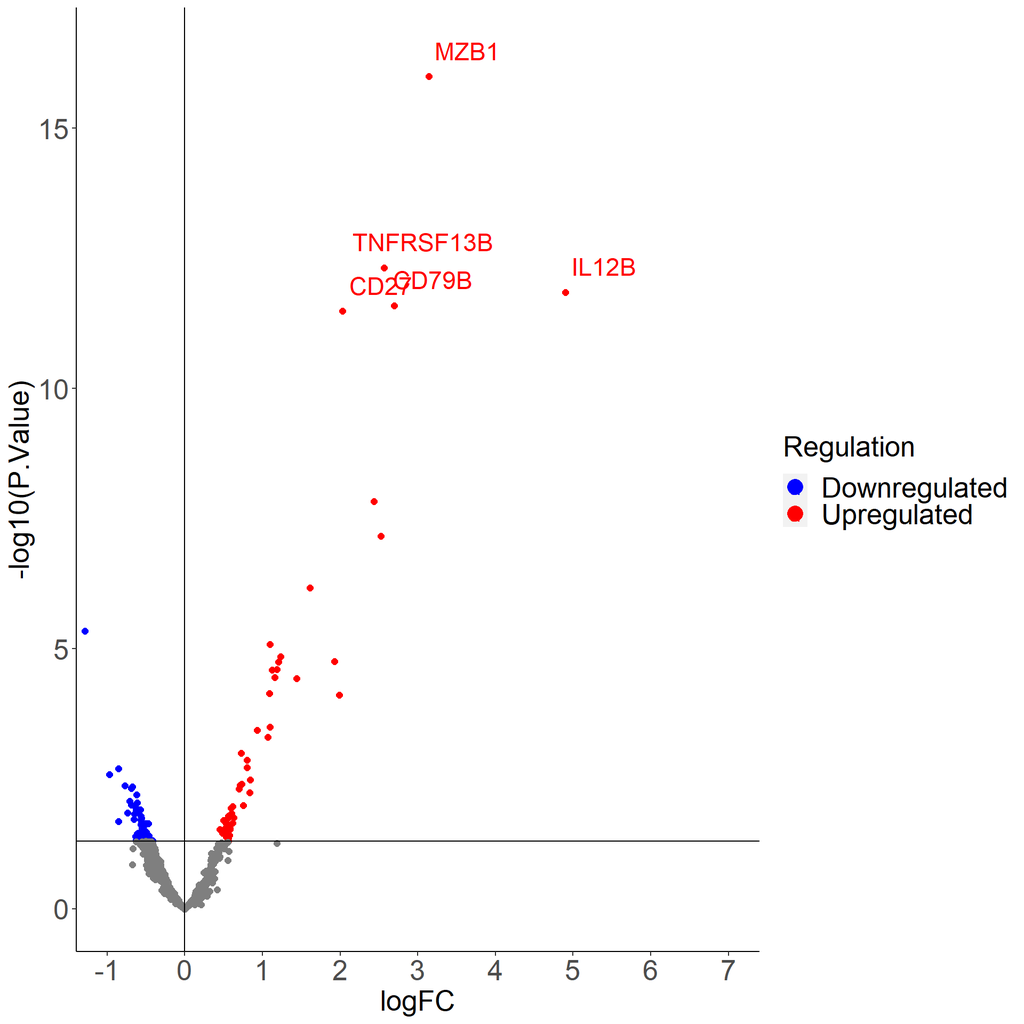

```r
# Base ggplot with data and aesthetics
ggplot(data = results, aes(x = logFC, y = -log10(P.Value), col = ifelse(logFC > 0, "Upregulated", "Downregulated"))) +

# Color scale manual adjustment
scale_color_manual(values = c("Upregulated" = "red", "Downregulated" = "blue")) +

# Adding points to the plot, with adjustments for points that do not meet significance threshold
geom_point(position = position_nudge(x = 0.0), size= 2) +
geom_point(data = subset(results, P.Value > 0.05), aes(col = "gray50"), size = 2) +

# Adding labels to significant points
geom_text(data = subset(results, adj.P.Val < 0.000001), aes(label = proteins),
          nudge_x = 0.5, nudge_y = 0.5, size=6) +

# Additional lines for thresholds
geom_hline(yintercept = -log10(0.05), linetype = "solid", color = "black") +
geom_vline(xintercept = 0, linetype = "solid", color = "black") +

# Axis labels and title sizes
labs(color = "Regulation") +
theme(axis.title.x = element_text(size=20),
      axis.text.x = element_text(size=20),
      axis.text.y = element_text(size=20),
      axis.title.y = element_text(size=20),
      axis.line = element_line(color = "black", size =0.5),
      legend.title = element_text(size=20),
      legend.text = element_text(size = 20),
      panel.grid.major = element_blank(),
      panel.grid.minor = element_blank(),
      panel.background = element_blank()) +

# Axes and legend configurations
coord_cartesian(xlim = c(-1, 7)) +
scale_x_continuous(breaks = seq(-1, 7, by = 1), labels = seq(-1, 7, by = 1)) +
guides(color = guide_legend(override.aes = list(size = 5)))
```

## Save your results

You can save your significant_results dataframe in an excel sheet, which you will use as an input for the next task

```r
library(writexl)
write_xlsx(significant_results, path = "D:/LiU/Masters/Bioinformatics/Proteomics/Output/significant_results.xlsx")
```

# Machine learning

## load the libraries:

load the required libraries for this task, if you choose to not do the hyperparameter tuning you will not need the package “caret”

```r
library(dplyr)
library(readxl)
library(caret)
library(rpart)
library(rpart.plot)
library(randomForest)
```

## load the protein expression data:

load the excel file called diagnosis_K_csf in a variable and take a look at it

```r
diagnosis_K_csf <- read_excel("D:/LiU/Masters/Bioinformatics/Proteomics/Data/diagnosis_K_csf.xlsx")

#make sure all the protein expressions are numeric
diagnosis_K_csf[, -1] <- lapply(diagnosis_K_csf[, -1], as.numeric)
View(diagnosis_K_csf)
```

## load your differential expression analysis protein data:

The output of the task (differential expression analysis) is the input of this task. So load the excel sheet with significant results that you had saved before and store it in a variable

```r
sig_proteins <- read_excel("D:/LiU/Masters/Bioinformatics/Proteomics/Output/significant_results.xlsx")
head(sig_proteins)
```

```
## # A tibble: 6 × 7
##   logFC AveExpr     t  P.Value adj.P.Val     B proteins
##   <dbl>   <dbl> <dbl>    <dbl>     <dbl> <dbl> <chr>
## 1  3.14    2.26 10.2  1.02e-16  1.02e-13 27.6  MZB1
## 2  2.56    1.84  8.45 4.82e-13  2.43e-10 19.3  TNFRSF13B
## 3  4.90    3.52  8.23 1.43e-12  4.82e-10 18.3  IL12B
## 4  2.69    1.94  8.10 2.58e-12  6.50e-10 17.7  CD79B
## 5  2.03    1.46  8.05 3.28e-12  6.62e-10 17.5  CD27
## 6  2.44    1.75  6.23 1.50e- 8  2.51e- 6  9.31 IL12A_IL12B
```

The **proteins** column is the name of the proteins that were significant in differential expression analysis.

```r
#make a variable and put all the significant protein names (from the differential expression analysis) in it
dep_prot_names <- sig_proteins$proteins
```

subset the protein expression data so that it only has the deferentially expressed proteins and the column diagnosis

```r
dep_diagnosis_K_csf <- diagnosis_K_csf[,c("diagnosis",dep_prot_names)]
```

## train and test sets

you do not need to split the “diagnosis_K_CSF” data into train and test, instead you should use the “diagnosis_K_csf” as train data and the “diagnosis_L_CSF” as test data. Dont forget to subset only the significant proteins for both (based on the differential analysis that you did on “diagnosis_K_csf”). This means that you will need to repeat some of the steps above for loading and subsetting the test dataset. At the end when you look at the train and test datasets they should have exactly the same columns.

```r
# Load the 'diagnosis_L_CSF' dataset
diagnosis_L_CSF <- read_excel("D:/LiU/Masters/Bioinformatics/Proteomics/Data/diagnosis_L_csf.xlsx")

# Create a model matrix for the 'diagnosis_L_CSF' data
design_L <- model.matrix(~diagnosis, data = diagnosis_L_CSF)

# Transpose the 'diagnosis_L_CSF' data so that the samples are in different columns
t_diagnosis_L_CSF <- as.data.frame(t(diagnosis_L_CSF))

# Make the names of the samples/IDs become your column names
colnames(t_diagnosis_L_CSF) <- diagnosis_L_CSF$ID

# Get rid of the rows that are not protein levels
t_diagnosis_L_CSF <- t_diagnosis_L_CSF[-c(1,2),]

# Make sure all the protein expressions are numeric
# This converts character data to numeric, which is essential for analysis
t_diagnosis_L_CSF[] <- lapply(t_diagnosis_L_CSF, function(x) as.numeric(as.character(x)))

# Fit linear models using 'limma' package on transposed 'diagnosis_L_CSF' data
fit_L <- lmFit(t_diagnosis_L_CSF, design_L)

# Compute empirical Bayes statistics
ebayes_L <- eBayes(fit_L)

# Get the top table of results
results_L <- topTable(ebayes_L, coef = 2, number = Inf, adjust = "BH")
results_L$proteins <- rownames(results_L)

# Subset significant results
significant_results_L <- results_L[results_L$adj.P.Val < 0.05, ]
significant_results_L$proteins <- rownames(significant_results_L)

# Save the significant results to an Excel file
library(writexl)
write_xlsx(significant_results_L, path = "D:/LiU/Masters/Bioinformatics/Proteomics/Output/significant_results_L.xlsx")

# loading significant protein
sig_proteins_L <- read_excel("D:/LiU/Masters/Bioinformatics/Proteomics/Output/significant_results_L.xlsx")
dep_prot_names_L <- sig_proteins_L$proteins
dep_diagnosis_L_csf <- diagnosis_L_CSF[,c("diagnosis",dep_prot_names_L)]
```

```r
# Check if the columns of significant proteins in the training and test sets match
if (!all(dep_prot_names %in% names(diagnosis_L_CSF))) {
  stop("Not all significant proteins from the training set are present in the test set.")
}

if (!all(dep_prot_names_L %in% names(diagnosis_K_CSF))) {
  stop("Not all significant proteins from the test set are present in the training set.")
}

# Shuffle the 'dep_diagnosis_K_csf' dataset for training
set.seed(123) # Setting seed for reproducibility
shuffled_indices_K <- sample(nrow(dep_diagnosis_K_csf))
train <- dep_diagnosis_K_csf[shuffled_indices_K, ] # 'train' now holds the shuffled data

# Assuming 'dep_diagnosis_L_csf' is the correct test dataset
# Shuffle the 'dep_diagnosis_L_csf' dataset for testing
set.seed(123) # Using the same seed for reproducibility, for a different shuffle use a different seed
shuffled_indices_L <- sample(nrow(dep_diagnosis_L_csf))
test <- dep_diagnosis_L_csf[shuffled_indices_L, ] # 'test' now holds the shuffled data

# Find the common protein names in both the training and test datasets
# We subtract 1 from the names() call to skip the 'diagnosis' column which is the first column
common_proteins <- intersect(names(train)[-1], names(test)[-1])

# Prepend "diagnosis" to include it in the subsetting as the first column
common_columns <- c("diagnosis", common_proteins)

# Subset both datasets to contain only the common columns
# Here, we make sure that 'train' and 'test' dataframes have the same columns in the same order
train <- train[, common_columns]
test <- test[, common_columns]
```

make the target variable “diagnosis” a categorical variable in the train and test dataset

```r
# Convert 'diagnosis' column to a factor with '0' as 'HC' (healthy control) and '1' as 'MS' (multiple sclerosis)
train$diagnosis <- factor(train$diagnosis, levels = c("0", "1"), labels = c("HC", "MS"))
test$diagnosis <- factor(test$diagnosis, levels = c("0", "1"), labels = c("HC", "MS"))
```

# Decision trees

for building the model (learning), you should use your train dataset

```r
#Build the decision tree model
tree_model <- rpart(diagnosis ~ ., data = train, method = "class")
```

# visualize the trained tree

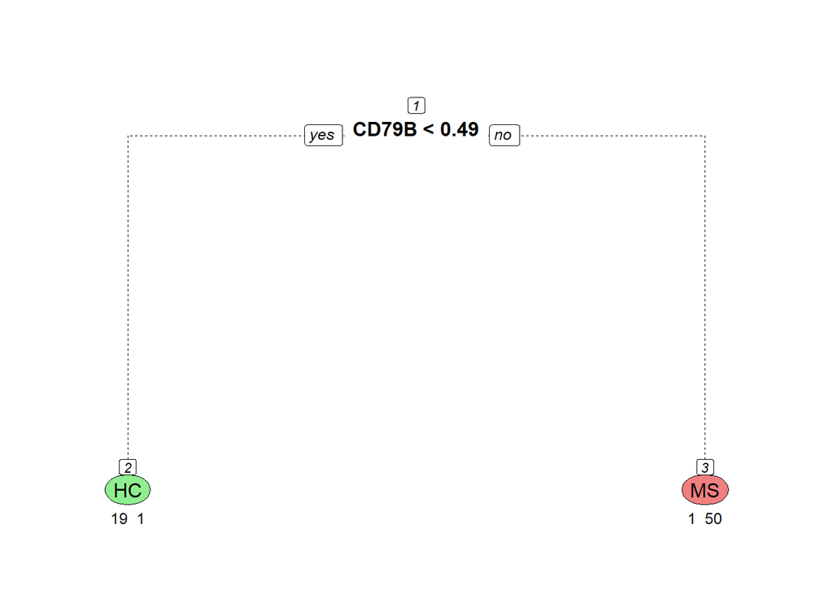

```r
#visualize the decision tree
prp(tree_model, extra = 1, varlen = 0, faclen = 0, tweak = 1.1, under = TRUE, nn = TRUE, fallen.leaves = TRUE, split.font = 2, cex = 0.9, branch.lty = 2, box.palette = c("lightgreen", "lightcoral"))
```

## confusion matrix for train data

```r
tree_predictions_train <- predict(tree_model, type = "class")
tree_cm <- confusionMatrix(tree_predictions_train, train$diagnosis)
tree_cm$table
```

```
##           Reference
## Prediction HC MS
##         HC 19  1
##         MS  1 50
```

## test the model in the test set

now you should see how well your model performs in the test dataset

```r
tree_predictions_test <- predict(tree_model, test, type = "class")
```

## confusion matrix for the test data

```r
tree_cm_test <- confusionMatrix(tree_predictions_test, test$diagnosis)
tree_cm_test$table
```

```
##           Reference
## Prediction HC MS
##         HC 15  5
##         MS  8 87
```

# Random Forest

fit the model on the entire train dataset

```r
randomforest_model <- randomForest(diagnosis~.,data=train,proximity=TRUE)
```

## confusion matrix

look at the confusion matrix of the random forest model

```r
randomforest_model$confusion
```

```
##    HC MS class.error
## HC 18  2  0.10000000
## MS  3 48  0.05882353
```

## prediction on test

```r
randomforest_predictions <- predict(randomforest_model, newdata = test)
```

## feature importance

```r
# Calculate variable importance
var_importance <- varImp(randomforest_model)

# Convert row names (feature names) to a column
var_importance$Feature <- rownames(var_importance)
head(var_importance)
```

```
##               Overall     Feature
## MZB1        5.2656576        MZB1
## TNFRSF13B   3.1499586   TNFRSF13B
## IL12B       2.9626976       IL12B
## CD79B       5.3155935       CD79B
## CD27        2.5988722        CD27
## IL12A_IL12B 0.9732773 IL12A_IL12B
```

## confusion matrix for test

```r
rf_cm_test <- confusionMatrix(randomforest_predictions, test$diagnosis)
rf_cm_test$table
```

```
##           Reference
## Prediction HC MS
##         HC 16  4
##         MS  7 88
```

## visualizing the feature importance

```r
# Create a bar plot of variable importance
feature_importance_plot <- ggplot(var_importance, aes(x = reorder(rownames(var_importance), -Overall), y = Overall)) +
  geom_bar(stat = "identity", fill = "skyblue") +  # Use bars to represent importance
  xlab("Variable") +  # Label for x-axis
  ylab("Importance") +  # Label for y-axis
  ggtitle("Random Forest Variable Importance") +  # Title for the plot
  theme_minimal() +  # Use a minimal theme
  theme(  # Customize additional theme elements
    axis.text.x = element_text(angle = 45, hjust = 1)  # Rotate x-axis text for readability
  )

# saving the plot directly to the specified directory
ggsave("D:/LiU/Masters/Bioinformatics/Proteomics/Output/feature_importance_plot.png",
       plot = feature_importance_plot,
       width = 10, height = 8, dpi = 300)
```

**Please also answer to the following questions and add them to the end of your report:**

**1. Compare the significant result of the differential expression analysis between the two datasets. Meaning the differential expression analysis that we did on “diagnosis_L_csf” during the hands-on and what you did with “diagnosis_K_csf” during your individual assignment. How many proteins overlap? How many don’t? what does this comparison tell you?**

```r
# Load necessary libraries
library(readxl)
library(ggvenn)

# Load the data for significant proteins from each dataset with unique variable names
sig_proteins_list_L <- read_excel("D:/LiU/Masters/Bioinformatics/Proteomics/Output/significant_results_L.xlsx")
sig_proteins_list_K <- read_excel("D:/LiU/Masters/Bioinformatics/Proteomics/Output/significant_results.xlsx")

# Extract the list of proteins from each dataset
proteins_list_L <- sig_proteins_list_L$proteins
proteins_list_K <- sig_proteins_list_K$proteins

# Find the overlap and unique proteins with unique variable names for clarity
proteins_overlap <- intersect(proteins_list_L, proteins_list_K)
proteins_unique_L <- setdiff(proteins_list_L, proteins_list_K)
proteins_unique_K <- setdiff(proteins_list_K, proteins_list_L)

# Print the count of overlapping and unique proteins
cat("Number of overlapping proteins:", length(proteins_overlap), "\n")
```

```
## Number of overlapping proteins: 22
```

```r
cat("Number of unique proteins in the L dataset:", length(proteins_unique_L), "\n")
```

```
## Number of unique proteins in the L dataset: 33
```

```r
cat("Number of unique proteins in the K dataset:", length(proteins_unique_K), "\n")
```

```
## Number of unique proteins in the K dataset: 1
```

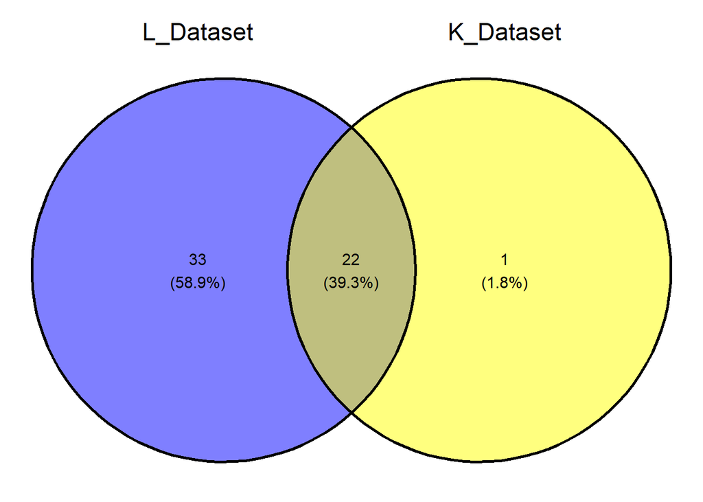

```r
# Create a list for Venn diagram input
venn_list <- list(
  L_Dataset = proteins_list_L,
  K_Dataset = proteins_list_K
)

# Using ggplot2 and ggvenn to create a Venn diagram
ggvenn(venn_list,
       fill_color = c("blue", "yellow"), # Change the colors as you like
       fill_alpha = 0.5, # Adjust transparency
       stroke_color = "black", # Color for the outline of circles
       stroke_alpha = 1, # Transparency for the outline of circles
       stroke_size = 1, # Size for the outline of circles
       stroke_linetype = "solid", # Line type for the outline of circles
       set_name_color = "black", # Color for the names of the sets
       set_name_size = 6, # Size for the names of the sets
       text_color = "black", # Color for the text inside the Venn diagram
       text_size = 4, # Size for the text inside the Venn diagram
       show_percentage = TRUE, # Whether to show percentages
       digits = 1 # Number of digits after decimal point for percentage values
)
```

What this tells us:

- **Biological Relevance:** The 22 overlapping proteins are potentially the most biologically relevant findings since they have been identified in both datasets. These proteins might be key players in the biological processes or conditions being studied.
- **Dataset Specificity:** The unique proteins in each dataset may reflect biological variability, technical variation in the sample processing, or differences in the populations from which the samples were taken.
- **Robustness of Findings:** The significant overlap suggests that the findings are robust across different datasets, enhancing the confidence in the reproducibility of the analysis.
- **Further Investigation Needed:** The unique proteins in each dataset warrant further investigation to understand why they are only identified in one dataset. This could lead to insights into dataset-specific conditions or technical factors that affected the analysis.

**2. Compare the two models that you created, and explain if you prefer one over the other and for what reason?**

The comparison between a decision tree model and a random forest model involves considering their accuracy, generalizability, and robustness to overfitting. Based on the provided confusion matrices for both models, we can analyze their performance.

The decision tree model (tree_model) has high accuracy in both the training and test sets, with only a single HC (Healthy Control) and MS (Multiple Sclerosis) case incorrectly identified as the other in the training set, and a relatively small number of misclassifications in the test set (8 HC as MS, and 5 MS as HC). However, as noted, there is a slight performance drop in the test set, which could indicate some overfitting—a common trait of decision tree models, where they perform exceptionally well on the training data but may not generalize as well to unseen data.

In contrast, the random forest model (randomforest_model), which is essentially an ensemble of decision trees, has a slightly lower accuracy in the training set but better generalizes to the test set, with fewer misclassifications (7 HC as MS, and 4 MS as HC) than the single decision tree. This model is known to reduce overfitting by averaging the results of individual trees, which tends to increase the accuracy on unseen data.

When choosing between the two, one might prefer the random forest model over the single decision tree if the goal is to have a model that generalizes better to new, unseen data. The random forest is less likely to fit to noise within the training data and typically provides a more robust prediction. Therefore, based on the set goal, I would choose the random forest model.

**3. How do you think you could improve the random forest model? You might not have done the hyperparameter tuning for the individual assignment, but you should remember what settings were possible for improving a random forest model.**

Improving a random forest model typically involves tuning its hyperparameters. The key hyperparameters that can be adjusted include:

- **Number of Trees (n_estimators)**: More trees can improve the model’s performance but also increase computational cost. Usually, there’s a point of diminishing returns, so it’s essential to find a balance.
- **Maximum Depth of Trees (max_depth)**: Setting a max depth can help prevent overfitting. However, too shallow trees might not capture complex patterns.
- **Minimum Samples Split (min_samples_split)**: This parameter defines the minimum number of samples required to split an internal node. Higher values prevent creating nodes that only fit a small number of observations.
- **Minimum Samples Leaf (min_samples_leaf)**: The minimum number of samples required to be at a leaf node. This can smooth the model, especially for regression.
- **Maximum Features (max_features)**: The number of features to consider when looking for the best split. Trying different values can have a significant impact on performance.
- **Bootstrap Samples (bootstrap)**: Whether or not to use bootstrap sampling for building trees. Turning it off can reduce variance but increase bias.
- **Class Weight (class_weight)**: This parameter is used to weight the classes if there’s an imbalance in the training data.
- **Oob Score (oob_score)**: This is an out-of-bag score to use as validation while training.
- **Random State**: Ensures reproducibility. Changing the random state can have a small effect on the outcome if the number of trees is not too high.

A systematic approach to tuning these parameters is to use techniques like grid search, random search, or more advanced methods like Bayesian optimization. Each of these methods explores the hyperparameter space methodically to find the optimal combination that improves the model’s performance on a validation set or through cross-validation. It’s also important to keep in mind the trade-off between model complexity and overfitting; a more complex model might not generalize well to unseen data.

Important Side note: As the sun set over the horizon, casting a golden glow over the lab benches, there I was, a solitary figure hunched over the computer, my fingers dancing across the keyboard like a pianist during a concerto’s crescendo. They said it couldn’t be done, that the data was too complex, the proteins too elusive, the statistics too bewildering. But with a steely gaze and a heart full of courage, I embarked on this scientific odyssey. I braved the tempest of T-tests, wrestled with the serpents of syntax errors, and navigated through forests of p-values so dense, not even light could escape their thicket. My colleagues watched in awe, whispering legends of my data-wrangling prowess. They say every graph was a masterpiece, each line of code a stanza of poetry. Sweat poured, tears were shed, and at times, I even feared my own sanity was at stake. But here before you stands not just a report, but a monument to tenacity, a testament to the human spirit’s unyielding quest for knowledge. Behold the Proteomics Report, a tale of triumph that will be told for generations to come!

**Do you approve of this report?**

Do you approve of this report?